# Lie Groups, Lie Algebras, and Representations Chapter 6 要旨

Author

March

Published

January 24, 2026

$$% Fields
\newcommand{\K}{\mathbb{K}}
\newcommand{\R}{\mathbb{R}}
\newcommand{\C}{\mathbb{C}}
\newcommand{\N}{\mathbb{N}}
\newcommand{\Z}{\mathbb{Z}}
% Lie Groups, Lie Algebras
\newcommand{\g}{\mathfrak{g}}
\newcommand{\h}{\mathfrak{h}}
\newcommand{\k}{\mathfrak{k}}
\newcommand{\o}{\operatorname{o}}
\newcommand{\u}{\operatorname{u}}
\newcommand{\gl}{\operatorname{gl}}
\newcommand{\sl}{\operatorname{sl}}
\newcommand{\so}{\operatorname{so}}
\newcommand{\su}{\operatorname{su}}
\newcommand{\sp}{\operatorname{sp}}
\newcommand{\O}{\operatorname{O}}
\newcommand{\U}{\operatorname{U}}
\newcommand{\GL}{\operatorname{GL}}
\newcommand{\SL}{\operatorname{SL}}
\newcommand{\SO}{\operatorname{SO}}
\newcommand{\SU}{\operatorname{SU}}
\newcommand{\Sp}{\operatorname{Sp}}
\newcommand{\Skew}{\operatorname{Skew}}
\newcommand{\SkewH}{\operatorname{SkewH}}
\newcommand{\End}{\operatorname{End}}
% Operatorns
\newcommand{\tr}{\operatorname{trace}}
\newcommand{\ad}{\operatorname{ad}}
\newcommand{\d}{\,\mathrm{d}}
\newcommand{\dd}[3][]{\frac{\text{d}^{#1}{#2}}{\text{d}^{#1}{#3}}}
\newcommand{\ang}[1]{\left\langle{#1}\right\rangle}
\newcommand{\Ad}{\operatorname{Ad}}
\newcommand{\Ker}{\operatorname{Ker}}
\renewcommand{\Im}{\operatorname{Im}}$$

# deconvolution density estimation に関する文献紹介

## $\mathbb{R}$ 上の deconvolution density estimation

Stefanski and Carroll (1990) の方法を紹介する． 確率変数 $Y$ に興味があるが，独立なノイズ $Z$ が加算された $X=Y+Z$ だけが観測できるという状況を考える．$X_1,\dots,X_n$ をつかって，$Y$ の分布を推定したい． ここでは，ノイズ分布の密度 $f_Z$ は既知とする．$X$ が従う分布の密度 $f_X$ は畳み込みによって，
$$f_X(x)=\int_{-\infty}^{\infty} f_Y(x-z)f_Z(z)\d{z}$$

と計算できる．有界で原点対称なカーネル $K:\R\to\R$ は $\int K(x)\d{x}=1$ を満たすとする．

$$\hat{f}_X(x)=\frac{1}{nh}\sum_{j=1}^{n}K\left(\frac{X_j-x}{h}\right)$$

によって，$X$ の密度を推定することにする．ここから逆畳み込みによって，$\hat{f}_{Y}$ を求める．$f_{X}$ の特性関数 $\phi_{X}$ は

$$\phi_X(t)=E[\exp(itX)]=\int_{-\infty}^{\infty}e^{itx}f_X(x)\d{x}$$

によって定まる．逆に $f_X$ は特性関数 $\phi_X$ を用いて，

$$f_X(x)=\frac{1}{2\pi}\int_{-\infty}^{\infty}e^{-itx}\phi_{X}(t)\d{t}$$

と表せる（Fourier 逆変換）．

特性関数の性質から，$\phi_{X}(t)=\phi_{Y}(t)\phi_{Z}(t)$ が成り立つことを利用して，

$$\hat{f}_{Y}(y)=\frac{1}{2\pi}\int_{-\infty}^{\infty}e^{-ity}\frac{\hat\phi_X(t)}{\phi_Z(t)}\d{t},\quad
\hat\phi_{X}(t)=\int_{-\infty}^{\infty}e^{itx}\hat{f}_{X}(x)\d{x}$$

によって，$f_Y$ を推定する．諸仮定の下で，$\hat{f}_Y$ は $f_Y$ に（各点で）確率収束する．

**$\hat{f}_Y$ の別表現**

$$\phi_K(t)=\int_{-\infty}^{\infty}e^{itx}K(x)\d{x}$$

を用いると，$\hat\phi_{X}$ は
$$\begin{align*}
\hat\phi_X(t)
&= \frac{1}{nh}\sum_{j=1}^{n}\int_{-\infty}^{\infty}e^{itx}K\left(\frac{X_j-x}{h}\right)\d{x}\\
&= \frac{1}{n}\sum_{j=1}^{n}\int_{-\infty}^{\infty}e^{it(X_j-hu)}K(u)\d{u}\\
&= \frac{1}{n}\sum_{j=1}^{n}e^{itX_j}\phi_K(-ht)
\end{align*}$$

と表せる．

$$K^*(u)=\frac{1}{2\pi}\int_{-\infty}^{\infty}e^{itu}\frac{\hat\phi_{K}(t)}{\phi_Z(t/h)}\d{t}$$

とすると，

$$\hat{f}_{Y}(y)=\frac{1}{nh}\sum_{j=1}^{n}K^*\left(\frac{X_j-y}{h}\right)$$

である．

## コンパクト群上の Fourier 解析

**Proposition 1** コンパクト群の任意の（有限次元）表現はあるユニタリ表現と同値

**証明**

*Proof*. コンパクト群 $G$ の表現を $(\Pi,V)$ とする．$V$ に任意の内積 $\ang{\,\cdot\,,\,\cdot\,}_0$ を定めて， $\Pi$ がユニタリになるような新たな内積 $\ang{\,\cdot\,,\,\cdot\,}$ を

$$\ang{v_1,v_2}:=\int_{G}\ang{\Pi(g)v_1,\Pi(g)v_2}_{0}\d{g}$$

で定める．ただし，$\mathrm{d}g$ は $\int_{G}\d{g}=1$ を満たす Haar 測度． $\ang{\,\cdot\,,\,\cdot\,}$ がユニタリであることを示す．

$$\begin{align*}
\ang{\Pi(g)v_1,\Pi(g)v_2}
&=\int_{G}\ang{\Pi(g)\Pi(g')v_1,\Pi(g)\Pi(g')v_2}_{0}\d{g'}\\
&=\int_{G}\ang{\Pi(gg')v_1,\Pi(gg')v_2}_{0}\d{g'}\\
&=\int_{G}\ang{\Pi(h)v_1,\Pi(h)v_2}_{0}\d{h}\\
&=\ang{v_1,v_2}
\end{align*}$$

2つの表現 $(\Pi,V),(\Pi,(V,\ang{\,\cdot\,,\,\cdot\,}))$ が同値なことは，$G$-準同型 (intertwining map) 全単射として恒等写像がとれることからすぐにわかる．

**Proposition 2** 位相群の既約表現と同値な任意の表現は既約

**証明**

*Proof*. Lie 群 $G$ 上の同値な表現 $(\Pi,V),(\Sigma,W)$ は $G$-同型 (intertwining map) 全単射 $\phi:V\to W$ によって，
$$\phi(\Pi(g)v)=\Sigma(g)\phi(v)$$

とできる．$(\Sigma,W)$ は既約とする．$V$ の任意の不変部分空間 $V'\subset V$ が $V'=\{0\}$ または $V'=V$ となることを示せばよい． $\phi(V')$ は $W$ の不変部分空間である．実際，任意の $w=\phi(v)\in\phi(V')$ に対して，
$$\Sigma(g)w=\phi(\Pi(g)v)\in\phi(V')$$

が成り立つ．ところが，$(\Sigma,W)$ は既約なので，$\phi(V')=\{0\}$ か $\phi(V')=W$ である．$\phi$ は全単射なので，$V'=\{0\}$ または $V'=V$ が成り立つ．

コンパクト群 $G$ の（有限次元）既約ユニタリ表現の同値類全体を $\hat{G}$ とする（代表元はあらかじめ選んでおく）．

**Note 1**

$G$ がコンパクト Lie 群なら，$\hat{G}$ は既約表現の同値類全体とみなせる（代表元はユニタリ表現を選ぶ）．

二乗可積分関数 $f:G\to\C$ に対して，Peter-Weyl の定理から以下の Fourier 変換公式が成り立つ (Folland 2016)．

$$\begin{align*}
\hat{f}(\Pi) &= \int f(g)\Pi(g^{-1})\d{g}\\
f(g) &= \sum_{[(\Pi,V)]\in\hat{G}}\dim{V}\tr[\hat{f}(\Pi)\Pi(g)]
\end{align*}$$

ただし，$\mathrm{d}g$ は $\int_{G}\d{g}=1$ を満たす Haar 測度．

## $\mathrm{SO}(N)$ の既約表現

コンパクト Lie 群 $\SO(N)$ の既約表現も，最高ウェイトを用いて分類できる．Lie 代数 $\so(N)$ のルート系が $N$ の偶奇によって異なるため，$\SO(N)$ の分類も $N$ の偶奇によって異なる（らしい）．

$\SU(3)$ が2つの非負整数の組で既約表現をラベルづけできるように，$\SO(N)$ の既約表現もシグネチャ (signature) と呼ばれる $k$ 個の整数の組でラベルづけできる．ここで，$N=2k+1$ あるいは $N=2k$ である．

$\SO(N)$ の既約表現全体は $N=2k+1$ の場合，
$$J = \{j\in\Z^{k}\mid j_1\geq j_2\geq\dots\geq j_k\geq0\}$$

$N=2k$ の場合，
$$J = \{j\in\Z^{k}\mid j_1\geq j_2\geq\dots\geq |j_k|\}$$

によってラベルづけできる．

## $\mathrm{SO}(N)$ 上の deconvolution density estimation

Kim (1998) の方法を紹介する． $\SO(N)$ 上の確率要素 $Y$ に興味があるが，$\SO(N)$ の独立なノイズ $Z$ が作用した $X=YZ$ だけが観測できるという状況を考える．$X_1,\dots,X_n$ をつかって，$Y$ の分布を推定したい． ここでは，ノイズ分布の密度 $f_Z$ は既知とする．$X$ の分布の $f_X$ は畳み込みによって，
$$f_X(x)=\int f_Y(z^{-1}x)f_Z(z)\d{z}$$

表される．$f_{X}$ のシグネチャ $j$ に対応するユニタリ既約表現 $\Pi_j$ についての Fourier 変換（特性関数）を $\phi_{X}(j)$ とすると，

$$\begin{align*}
\phi_{X}(j)
&=\int f_{X}(x)\Pi_{j}(x^{-1})\d{x}\\
&=\iint f_{Y}(z^{-1}x)f_{Z}(z)\Pi_{j}(x^{-1})\d{z}\d{x}\\
&=\iint f_{Y}(y)f_{Z}(z)\Pi_{j}(y^{-1}z^{-1})\d{z}\d{y}\\
&=\left(\int f_{Y}(y)\Pi_{j}(y^{-1})\d{y}\right)\left(\int f_{Z}(z)\Pi_{j}(z^{-1})\d{z}\right)\\
&=\phi_{Y}(j)\phi_Z(j)
\end{align*}$$

が成り立つ．$\phi_{Z}(j)$ は可逆と仮定すると，$\phi_{Y}(j)=\phi_{X}(j)\phi_{Z}(j)^{-1}$ である．

**Tip 1**

これらの既約表現は Laplacian の固有関数をつかって表せるようだ．

**Tip 2**

論文の例では $\phi_{Z}(j)$ を（可逆になるように）直接指定している．

$X$ の経験特性関数
$$\hat\phi_X(j)=\frac{1}{n}\sum_{i=1}^{n}\Pi_{j}(X_i^{-1})$$

を用いて，
$$\hat{f}_{Y}(y)=\sum_{j\in J_m}d_j\tr[\hat\phi_{X}(j)\phi_{Z}(j)^{-1}\Pi_{j}(y)]$$

によって，$f_Y$ を推定する．ただし，$J_m=\{j\in J\mid m\geq j_1\}$ である．また，表現 $(\Pi_j,V_j)$ に対し，$d_j=\dim{V_j}$ とした．$\hat{f}_Y$ も諸仮定の下で，$f_Y$ に（各点で）確率収束する．

$$K^*(g) = \sum_{j\in J_{m}}d_j\tr[\phi_{Z}(j)^{-1}\Pi_{j}(g)]$$

とすると，
$$\hat{f}_{Y}(y) = \frac{1}{n}\sum_{i=1}^{n}K^*(X_{i}^{-1}y)$$

とも表せる．

- コンパクト Lie 群であることのポイントは既約表現が（Lie 代数を使って？）分類できること．
- コンパクト群であることのポイントは Fourier 変換ができること．

# 6.1 Preliminaries

- $\sl(3;\C)$ の既約表現は最高ウェイトによって分類できること (Theorem 3) を示すのがこの章の目標．一般論は以降の章で．
- $\SU(3)$ の表現は物理で重要．$\sl(3;\C)\simeq\su(3)_\C$ によって，$\sl(3;\C)$ の表現を調べることで $\SU(3)$ の表現を調べることができる (Theorem 5)．
- 5章の結果は使わない（4章の復習だけでひとまずは OK）．

# 4 章の復習

- Lie 群 $G$ の表現 (representation) とは，Lie 群の準同型 $\Pi:G\to\GL(V)$ のこと．$V$ は線形空間，$\GL(V)$ は $V\to V$ の正則な線形写像全体．
- Lie 代数 $\g$ の表現とは，Lie 代数の準同型 $\pi:\g\to\gl(V)$ のこと．$\gl(V)$ は $V\to V$ の線形写像全体．
- $V,W$ は線形空間，$\Pi,\Sigma$ は $V,W$ に作用する $G$ の表現とする．線形写像 $\phi:V\to W$ が $G$-準同型（絡写像；intertwining map）とは，$\phi(\Pi(A)v)=\Sigma(A)\phi(v)$ となること．Lie 代数についても同様．共変性のことだ．
  - $\Pi,\Sigma$ が同型 (isomorphic) とは，$G$-準同型な全単射 $\phi$ が存在すること．

## 既約表現

**Definition 1 (Hall (2015) Definition 4.2)** $(\Pi,V)$ を Lie 群 $G$ の（有限次元）表現とする．$V$ の部分空間 $W$ が**不変 (invariant)** であるとは，
$$\{\Pi(A)w \mid A\in G, w\in W\}\subset W$$

となること．$(\Pi,V)$ が**既約 (irreducible)** であるとは，不変部分空間が $W=\{0\}$ と $W=V$ に限ること．

Lie 代数 $\g$ の表現 $(\pi,V)$ についても同様に定義する．

## $\mathrm{sl}(2;\mathbb{C})$ の表現

$\sl(2;\C)$ の基底として，以下を用いる．
$$\begin{align*}
H=\begin{pmatrix}1&0\\0&-1\end{pmatrix},
&&X=\begin{pmatrix}0&1\\0&0\end{pmatrix},
&&Y=\begin{pmatrix}0&0\\1&0\end{pmatrix}
\end{align*}$$

**Theorem 1 (Hall (2015) Theorem 4.32)** $\sl(2;\C)$ の既約表現について，以下が成立する．

1. 任意の非負整数 $m$ に対し，次元が $m+1$ の既約表現が存在する
2. 次元が等しい既約表現は同型
3. 次元が $m+1$ の既約表現は $(\pi_m,V_m)$ と同型（Example 4.10 を参照）

**Theorem 2 (Hall (2015) Theorem 4.34)** $(\pi,V)$ を $\sl(2;\C)$ の表現とする．

1. $\pi(H)$ の任意の固有値 $\lambda$ は整数で，その固有ベクトル $v$ が $\pi(X)v=0$ を満たすなら，$\lambda$ は非負．
2. $\pi(X),\pi(Y)$ は冪零 (nilpotent)．
3. $S=e^{\pi(X)}e^{-\pi(Y)}e^{\pi(X)}$ は $S\pi(H)S^{-1}=-\pi(H)$ を満たす．
4. 整数 $k$ が $\pi(H)$ の固有値なら，$-|k|,-|k|+2,\dots,|k|-2,|k|$ も $\pi(H)$ の固有値．

# 6.2 Weights and Roots

$\sl(3;\C)$ の基底として，以下を用いる．
$$\begin{align*}
H_{1}&=\begin{pmatrix}1&0&0\\0&-1&0\\0&0&0\end{pmatrix},
&H_{2}&=\begin{pmatrix}0&0&0\\0&1&0\\0&0&-1\end{pmatrix},\\[5pt]
X_{1}&=\begin{pmatrix}0&1&0\\0&0&0\\0&0&0\end{pmatrix},
&X_{2}&=\begin{pmatrix}0&0&0\\0&0&1\\0&0&0\end{pmatrix},
&X_{3}&=\begin{pmatrix}0&0&1\\0&0&0\\0&0&0\end{pmatrix},\\[5pt]
Y_{1}&=\begin{pmatrix}0&0&0\\1&0&0\\0&0&0\end{pmatrix},
&Y_{2}&=\begin{pmatrix}0&0&0\\0&0&0\\0&1&0\end{pmatrix},
&Y_{3}&=\begin{pmatrix}0&0&0\\0&0&0\\1&0&0\end{pmatrix}
\end{align*}$$

Table 1: ブラケットの関係

| $[\text{行},\text{列}]$ | $H_1$ | $H_2$ | $X_1$ | $X_2$ | $X_3$ | $Y_1$ | $Y_2$ | $Y_3$ |
| --- | --- | --- | --- | --- | --- | --- | --- | --- |
| $H_1$ |  | $0$ | $2X_1$ | $-X_2$ | $X_3$ | $-2Y_1$ | $Y_2$ | $-Y_3$ |
| $H_2$ |  |  | $-X_1$ | $2X_2$ | $X_3$ | $Y_1$ | $-2Y_2$ | $-Y_3$ |
| $X_1$ |  |  |  | $X_3$ | $0$ | $H_1$ | $0$ | $-Y_2$ |
| $X_2$ |  |  |  |  | $0$ | $0$ | $H_2$ | $0$ |
| $X_3$ |  |  |  |  |  | $-X_2$ | $X_1$ | $H_1+H_2$ |
| $Y_1$ |  |  |  |  |  |  | $-Y_3$ | $0$ |
| $Y_2$ |  |  |  |  |  |  |  | $0$ |
| $Y_3$ |  |  |  |  |  |  |  |  |

**Definition 2 (Hall (2015) Definition 6.1 ウェイト)** $(\pi,V)$ を $\sl(3;\C)$ の表現とする．複素数の組 $\mu=(m_1,m_2)\in\C^2$ が $\pi$ の**ウェイト (weight)** であるとは，$0$ でない $v\in V$ が存在して，
$$\begin{align*}
\pi(H_1)v&=m_1v\\
\pi(H_2)v&=m_2v
\end{align*}$$

が成立すること．

**Note 2**

$\mu$ が $\pi$ のウェイトであるとは，$\pi(H_1),\pi(H_2)$ の固有ベクトル $v$ に対する固有値の組であること．

- $v$ をウェイト $\mu$ に対する**ウェイトベクトル (weight vector)**という．
- ウェイト $\mu$ に対するウェイトベクトル全体を**ウェイト空間 (weight space)** という．ウェイト空間は複素線形空間．
- ウェイト $\mu$ の**重複度 (multiplicity)** とは，ウェイト空間の次元のこと．

**Proposition 3 (Hall (2015) Proposition 6.2)** $\sl(3;\C)$ の任意の表現 $(\pi,V)$ は少なくとも1つのウェイトをもつ．

*Proof*. $[H_1,H_2]=0$ より，**$\pi(H_1),\pi(H_2)$ は可換**．

**Note 3**

$0=\pi([H_1,H_2])=[\pi(H_1),\pi(H_2)]=\pi(H_1)\pi(H_2)-\pi(H_2)\pi(H_1)$ から従う．

$\pi(H_1)$ のある固有値 $m_1\in\C$ を選んで，その固有空間を $W$ とする． 任意の $w\in W$ に対し，$\pi(H_1)(\pi(H_2)w)=\pi(H_2)\pi(H_1)w=m_1\pi(H_2)w$ より，$\pi(H_2)w\in W$ である． したがって，$\pi(H_2)|_{W}$ は $W$ から $W$ 自身への線形写像で，固有値 $m_2\in\C$ と固有ベクトル $v\in W$ をもつ．

$\mu:=(m_1,m_2)$ はウェイトベクトル $v$ に対するウェイトである．

**Proposition 4 (Hall (2015) Proposition 6.3)** $\sl(3;\C)$ の表現 $(\pi,V)$ の任意のウェイト $\mu=(m_1,m_2)$ は整数の組．

*Proof*. $i\in\{1,2\}$ に対し，$\langle H_i,X_i,Y_i \rangle\simeq \sl(2;\C)$ である．この同一視によって，$(\pi|_{\langle H_i,X_i,Y_i \rangle},V)$ は $\sl(2;\C)$ の表現である．Theorem 2 1. より，$\pi(H_i)$ の任意の固有値は整数なので，$m_i$ は整数．

**Definition 3 (Hall (2015) ルート)** 複素数の組 $\alpha=(a_1,a_2)\in\C^2$ が**ルート (root)** であるとは，$\alpha\neq(0,0)$ で，$0$ でない $Z\in\sl(3;\C)$ が存在して，
$$\begin{align*}
[H_1,Z]&=a_1Z\\
[H_2,Z]&=a_2Z
\end{align*}$$

が成立すること．

**Note 4**

$\alpha$ がルートであるとは，表現 $(\ad,\sl(3;\C))$ の非零ウェイトであること．

- $Z$ を**ルートベクトル (root vector)** という．
- Proposition 4 より，$\alpha\in\Z^2$

Table 1 から，6つのルートが得られる．

Table 2

| $\alpha$ | $Z$ |
| --- | --- |
| $(2,-1)$ | $X_1$ |
| $(-1,2)$ | $X_2$ |
| $(1,1)$ | $X_3$ |

| $\alpha$ | $Z$ |
| --- | --- |
| $(-2,1)$ | $Y_1$ |
| $(1,-2)$ | $Y_2$ |
| $(-1,-1)$ | $Y_3$ |

- $\sl(3;\C)$ のルートは Table 2 に限る．
- $\alpha_1=(2,-1),\alpha_2=(-1,2)$ を**正単純ルート (positive simple root)** という．
- 正単純ルート $\alpha_1,\alpha_2$ は任意のルートを整数係数の線形結合で表せて，その係数はすべて非負かすべて非正．

**Lemma 1 (Hall (2015) Lemma 6.5)** $\sl(3;\C)$ の表現 $(\pi,V)$ のウェイトとウェイトベクトルを $\mu=(m_1,m_2)\in\Z^2,v\in V$ とする． $\sl(3;\C)$ のルート $\alpha=(a_1,a_2)\in\Z^2$ とそのルートベクトル $Z_\alpha\in\sl(3;\C)$ に対し，
$$\begin{align*}
\pi(H_1)\pi(Z_\alpha)v &= (m_1+a_1)\pi(Z_\alpha)v\\
\pi(H_2)\pi(Z_\alpha)v &= (m_2+a_2)\pi(Z_\alpha)v
\end{align*}$$
が成立．

**Note 5**

$\pi(Z_\alpha)v\neq0$ ならば，$\pi(Z_\alpha)v$ はウェイト $\mu+\alpha$ のウェイトベクトルになる．

*Proof*. $i\in\{1,2\}$ に対して，
$$\pi(H_i)\pi(Z_\alpha)-\pi(Z_\alpha)\pi(H_i)=[\pi(H_i),\pi(Z_\alpha)]=\pi([H_i,Z_\alpha]) = a_i\pi(Z_\alpha)$$

が成り立つので，

$$\pi(H_i)\pi(Z_\alpha)v
=\pi(Z_\alpha)\pi(H_i)v+a_i\pi(Z_\alpha)v
=(m_i+\alpha_i)\pi(Z_\alpha)v$$

# 6.3 The Theorem of the Highest Weight

**Definition 4 (Hall (2015) Definition 6.6 最高ウェイト)** $\sl(3;\C)$ の表現 $(\pi,V)$ のウェイト $\mu_1,\mu_2$ に対し，半順序 $\succeq$ を
$$\mu_1\succeq\mu_2\iff\exists a,b\geq0,\mu_1-\mu_2 = a\alpha_1+b\alpha_2$$

で定める．$\pi$ のウェイト $\mu_0$ が**最高ウェイト (highest weight)** であるとは，$\pi$ の任意のウェイト $\mu$ に対し，$\mu_0\succeq\mu$ となること．

**$\succeq$ が半順序であること**

反射律 $\mu\succeq\mu$：$a=b=0$ がとれる．

推移律 $\mu_1\succeq\mu_2\succeq\mu_3\Rightarrow\mu_1\succeq\mu_3$：

$\mu_1-\mu_2=a\alpha_1+b\alpha_2,\mu_2-\mu_3=c\alpha_1+d\alpha_2$ とすると，
$$\mu_1-\mu_3=(a+c)\alpha_1+(b+d)\alpha_2$$

反対称律 $\mu_1\succeq\mu_2,\mu_2\succeq\mu_1\Rightarrow\mu_1=\mu_2$：

$\mu_1-\mu_2=a\alpha_1+b\alpha_2,\mu_2-\mu_1=c\alpha_1+d\alpha_2$ とすると，$0=(a+c)\alpha_1+(b+d)\alpha_2$ だが，$\alpha_1,\alpha_2$ は線形独立なので $a=-c,b=-d$ である． 非負性の要請から $a=b=0$ となる．

**Theorem 3 (Hall (2015) Theorem 6.7 最高ウェイト定理)** $(\pi,V)$ を $\sl(3;\C)$ の既約表現とする．

1. $V$ はウェイト空間の直和（ i.e. $\pi(H_1),\pi(H_2)$ は同時対角化可能）
2. $\pi$ は唯一の最高ウェイトをもつ
3. $\pi$ と同じ最高ウェイトをもつ $\sl(3;\C)$ の既約表現は $(\pi,V)$ と同型
4. $\pi$ の最高ウェイトは非負整数の組
5. 任意の非負整数の組を最高ウェイトにもつ $\sl(3;\C)$ の既約表現が存在する

**Theorem 4 (Hall (2015) Theorem 6.8)** Theorem 3 5. の既約表現を誘導する $\SU(3;\C)$ の表現が存在する．

**Note 6**

$\sl(2;\C)$ でも同じような結果が成り立つ．$(\pi,V)$ を $\sl(2;\C)$ の表現とする．

1. $V$ は固有空間の直和（ i.e. $\pi(H)$ は対角化可能）
2. $\pi(H)$ は唯一の最大固有値をもつ
3. $\sl(2;\C)$ の表現 $(\sigma,W)$ について，$\sigma(H)$ の最大固有値が $\pi(H)$ の最大固有値と等しいなら，$(\pi,V)$ と $(\sigma,W)$ は同型
4. $(\pi,V)$ が既約なら，$\pi(H)$ の最大固有値は非負整数
5. 任意の非負整数 $m$ について，$\sigma(H)$ の最大固有値が $m$ であるような既約表現 $(\sigma,W)$ が存在する

Theorem 1 から，表現の次元と最大固有値は全単射？

- $\mu\in\Z^2$ を満たすウェイト $\mu$ を**整ウェイト (integral element)** という．
- $\mu\in\R_+^2$ を満たすウェイト $\mu$ を**優ウェイト (dominant)**という．
- 既約表現の最高ウェイトは整かつ優．

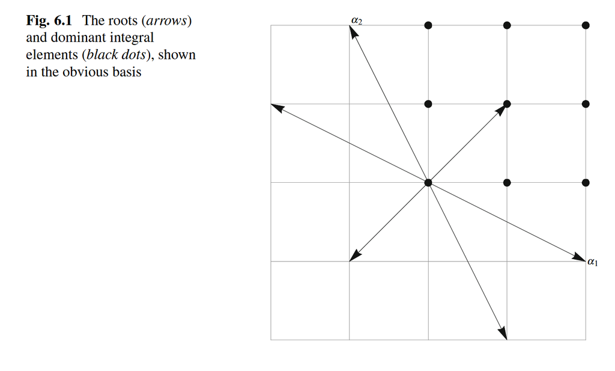

Hall (2015) Fig. 6.1

# 6.4 Proof of the Theorem

## 準備

$V$ は線形空間とする．$\mathcal{A}$ は $V$ 上の線形作用素の（線形）空間とする．

**Definition 5 (Hall (2015) Definition A.14)** 線形汎関数 $\mu\colon\mathcal{A}\to\R$ が $\mathcal{A}$ のウェイトであるとは，ある零でない $v\in V$ が存在して，
$$Av=\mu(A)v$$
が成立すること．

- $v$ をウェイトベクトルという．
- ウェイト空間とは，ウェイトベクトル全体のこと．

**Proposition 5 (Hall (2015) Proposition A.17)** $\mu_1,\dots,\mu_m$ は $\mathcal{A}$ の相異なるウェイトとする．対応するウェイトベクトル $v_1,\dots,v_m$ が $v_1+\cdots+v_m=0$ を満たすなら，$v_1=\cdots=v_m=0$．

さらに，$v_1+\cdots+v_m$ があるウェイト $\mu$ のウェイトベクトルならば，ある $j\in\{1,\dots,m\}$ が存在して，$\mu=\mu_j$ かつ，任意の $k\neq j$ に対して $v_k=0$．

*Proof*. 1つ目の主張は $m$ に関する帰納法で示す． $m=1$ の場合は明らか．

$v\coloneqq v_1+\cdots+v_m=0$ を仮定する． $\mu_{1}(A)\neq\mu_m(A)$ を満たすような $A\in\mathcal{A}$ を選ぶ．
$$0=(A-\mu_m(A)I)v=\sum_{j=1}^{m}(\mu_j(A)-\mu_m(A))v_j=\sum_{j=1}^{m-1}(\mu_j(A)-\mu_m(A))v_j$$

が成り立つ．帰納法の仮定から，$(\mu_j(A)-\mu_m(A))v_j=0$ が任意の $j=1,\dots,m-1$ に対して成り立つ．特に，$\mu_1(A)\neq\mu_m(A)$ より，$v_1=0$ である．今度は，$\mu_2(A)\neq\mu_m(A)$ を満たすような $A\in\mathcal{A}$ を選ぶことで，$v_2=0$ も示せる．これを繰り返して，$v_1=\cdots=v_{m-1}=0$ を得る．よって，$v_m=0$ も得られる．

2つ目の主張を示す． $v\coloneqq v_1+\cdots+v_m\neq0$ があるウェイト $\mu$ のウェイトベクトルであるとする．
$$0=(A-\mu(A)I)v=\sum_{k=1}(\mu_k(A)-\mu(A))\mu_k$$

が各 $A\in\mathcal{A}$ で成り立つ．このとき，1つ目の主張から，$(\mu_k(A)-\mu(A))v_k=0$ が任意の $k=1,\dots,m$ で成り立つ．$v_j\neq0$ となる $j$ が（$v\neq0$ より）存在するので，$\mu_j=\mu$ である．また，各 $k\neq j$ について，$\mu_k(A)\neq\mu(A)$ となる $A\in\mathcal{A}$ が選べるので，$v_k=0$ も成り立つ．

## Theorem 6.7-1

**Proposition 6 (Hall (2015) Proposition 6.9)** $\sl(3;\C)$ の任意の既約表現 $(\pi,V)$ について，$V$ はウェイト空間の直和．すなわち，$\pi(H_1),\pi(H_2)$ は同時対角化可能．

**Tip 3**

ウェイト空間の和は直和になる．Hall (2015) Proposition A.17 を参照．

*Proof*. ウェイト $\mu$ に関するウェイト空間を $W_\mu$ とする． $W\subset V$ を $V$ のウェイト空間の直和とする．$W$ が不変部分空間ならば，（表現の既約性から）$W=\{0\}$ または $W=V$ である．

- $W$ は $\pi(H_1),\pi(H_2)$ の同時固有ベクトルの線形結合全体である．
- Proposition 3 より，$\pi$ は少なくとも1つのウェイトをもつので，$W\neq\{0\}$ である．

$Z_\alpha$ をルート $\alpha$ に関するルートベクトルとする． Lemma 1 より，$\pi(Z_\alpha)\colon W_\mu\to W_{\mu+\alpha}$ なので，$W$ は $\pi(Z_\alpha)$ の作用に閉じている． Table 2 より，$Z_\alpha$ として，$X_i,Y_i,\enspace i=1,2,3$ が取れる． $W$ は $\pi(H_1),\pi(H_2)$ の作用にも閉じているので，$W$ は不変部分空間である．

## Theorem 6.7-2

**Definition 6 (Hall (2015) Definition 6.10 最高ウェイト巡回表現)** $\sl(3;\C)$ の表現 $(\pi,V)$ がウェイト $\mu=(m_1,m_2)\in\C^2$ に関する**最高ウェイト巡回表現 (highest weight cyclic representation)** であるとは，$0$ でない $v\in V$ が存在して，

1. $v$ は $\mu$ のウェイトベクトル．
2. $\pi(X_i)v=0,\quad i=1,2,3$．
3. $v$ を含む最小の不変部分空間は $V$ 自身．

が成り立つこと．

**Proposition 7 (Hall (2015) Proposition 6.11)** $\sl(3;\C)$ の $\mu$ に関する最高ウェイト巡回表現 $(\pi,V)$ について，以下が成立する．

1. $\mu$ は最高ウェイト．
2. $\mu$ に関するウェイト空間は1次元．

*Proof*. Definition 6 の $v\in V$ について，$W\subset V$ を次の形の元が張る部分空間とする：
$$w=\pi(Y_{j_1})\pi(Y_{j_2})\cdots\pi(Y_{j_N})v.$$
ただし，$N\geq0,\,j_1,\dots,j_N\in\{1,2,3\}$ である．$N=0$ の場合は $w=v$ とする．

$W$ が不変部分空間であることが次の手続きで確認できる．

1. Reordering Lemma によって，任意の $w$ は $\pi(X_1),\dots,\pi(X_3),\pi(H_1),\pi(H_2),\pi(Y_1),\dots,\pi(Y_3)$ の順で $v$ に作用する項の線形結合で表せる．
2. $v$ の定義から，$\pi(X_1),\dots,\pi(X_3)$ の指数が $0$ でない項は $0$ になる．よって，任意の $w$ は $\pi(H_1),\pi(H_2),\pi(Y_1),\dots,\pi(Y_3)$ の順で $v$ に作用する項の線形結合で表せる．
3. $v$ の定義から，$v$ は $\pi(H_1),\pi(H_2)$ の固有ベクトル．よって，任意の $w$ は $\pi(Y_1),\dots,\pi(Y_3)$ の順で $v$ に作用する項の線形結合で表せる．

よって，$v$ の定義から，$W=V$ が成り立つ．

$Y_1,Y_2,Y_3$ はそれぞれルート $-\alpha_1,-\alpha_2,-\alpha_1-\alpha_2$ に対応するルートベクトルである．よって，Lemma 1 より，$N>0$ について，$w=\pi(Y_{j_1})\pi(Y_{j_2})\cdots\pi(Y_{j_N})v$ は $w=0$ または $\mu$ 未満のウェイトに関するウェイトベクトル． したがって，$\mu$ は最高ウェイトで，$\mu$ に関するウェイトベクトルは $v$ の定数倍に限る．

Proposition 7 の証明には，次の Reordering Lemma を用いた．一般の半単純 Lie 代数に対しても便利な補題らしい．

**Lemma 2 (Hall (2015) Lemma 6.12 Reordering Lemma)** Lie 代数 $\g$ の表現を $(\pi,V)$ とする．$\g$ の線形空間としての基底を $X_1,\dots,X_m$ とすると，任意の $\pi(X_{j_1})\pi(X_{j_2})\cdots\pi(X_{j_N})$ は 次の形の項の線形結合で表せる：
$$\pi(X_m)^{k_m}\pi(X_{m-1})^{k_{m-1}}\cdots\pi(X_1)^{k_1}.$$

ただし，$k_1,\dots,k_m$ は非負整数で $k_1+k_2+\cdots+k_m\leq N$ を満たす．

*Proof*. $N$ に関する帰納法で示す．$N=1$ の場合は明らか． 帰納法の仮定から，$\pi(X_{j_1})\pi(X_{j_2})\cdots\pi(X_{j_N})$ は
$$\pi(X_{j_1})\pi(X_m)^{k_m}\pi(X_{m-1})^{k_{m-1}}\cdots\pi(X_1)^{k_1}$$

という形の項の線形結合で表せる．ただし，$k_1+k_2+\cdots+k_m\leq N-1$. ここで，$\g$ の括弧積は（基底 $X_1,\dots,X_m$ に関する）構造定数をつかって，$[X_j,X_k] =\sum_{l=1}^{m}c_{jkl}X_l$ と表せるので，

$$\pi(X_j)\pi(X_k)
= \pi(X_k)\pi(X_j) + \pi([X_j,X_k])
= \pi(X_k)\pi(X_j) + \sum_{l=1}^{m}c_{jkl}\pi(X_l)$$

が成り立つ．

**Tip 4**

積の順序が入れ替わった項と，（積に関する）次数が1つ落ちた項に分解できるのが肝．

この関係を使って，積の順序を入れ替えることができる．次数が1つ落ちた項 $\sum_{l=1}^{m}c_{jkl}\pi(X_l)$ についても同様に，積の順序を入れ替えていく．この並べ替えは有限回で完了する．

**Proposition 8 (Hall (2015) Propsition 6.13)** $\sl(3;\C)$ の任意の既約表現 $(\pi,V)$ は唯一の最高ウェイト $\mu$ に関する最高ウェイト巡回表現．

*Proof*. Proposition 6 より，$V$ はウェイト空間の直和．$V$ は有限次元なので，ウェイトも有限個しか存在しない．よって，極大なウェイト $\mu$（$\mu$ 以上のウェイトが存在しないもの）が少なくとも1つ存在する．

そのような $\mu=(m_1,m_2)$ とそのウェイトベクトル $v$ について，Lemma 1 と $\mu$ が極大であることから，$\pi(X_i)v=0,\enspace i=1,2,3$ である．

また，$(\pi,V)$ の既約性から，$v$ を含む最小の不変部分空間は $V$ 自身である．よって，$(\pi,V)$ は極大ウェイト $\mu$ に関する最高ウェイト巡回表現で，Proposition 7 より，$\mu$ は最高ウェイト．

## Theorem 6.7-3

**Proposition 9 (Hall (2015) Proposition 6.14)** $\sl(3;\C)$ の完全可約な最高ウェイト巡回表現 $(\pi,V)$ は既約．

*Proof*. $(\pi,V)$ は完全可約なので，ある既約表現 $(\pi_j,V_j),\enspace i=1,\cdots,m$ が存在して，
$$V\simeq\bigoplus_{j=1}^{m}V_j$$
が成り立つ．$m=1$ となることを示す．

$(\pi,V)$ の最高ウェイトとそのウェイトベクトルを $\mu,v$ とする． このとき，ある $V_j$ が存在して，ウェイト $\mu$ をもつ（Hall (2015) Proposition A.17 を参照）．しかも，Proposition 7 から，$\mu$ に関するウェイト空間は1次元なので，ウェイト $\mu$ をもつのは $V_j$ に限る． $V_j$ は $V$ の不変部分空間なので，最高ウェイト巡回表現の定義から，$V_j=V$ である．以上より，$V$ は既約．

**Proposition 10 (Hall (2015) Proposition 6.15)** $\sl(3;\C)$ の2つの既約表現 $(\pi,V),(\sigma,W)$ は同じ最高ウェイトをもつとする．$(\pi,V)$ と $(\sigma,W)$ は同型．

*Proof*. $(\pi,V),(\sigma,W)$ の最高ウェイトを $\mu$ として，それぞれの最高ウェイトベクトルを $v\in V,w\in W$ とする．直和表現 $(\pi\oplus\sigma,V\oplus W)$ を考える．$U$ を $(v,w)$ を含む $V\oplus W$ の最小の不変部分空間とする．$(\pi\oplus\sigma,U)$ は $\mu$ に関する最高ウェイト巡回表現である． 完全可約表現の不変部分空間もまた完全可約（Hall (2015) Proposition 4.26）なので，$U$ は完全可約．Proposition 9 より，$U$ は既約．

$V\oplus W$ から $V,W$ への射影を $P_V(v,w)\coloneqq v,P_W(v,w)\coloneqq w$ で定める．$P_V,P_W$ は $\sl(3;\C)$-準同型なので，$P_V|_U,P_W|_U$ もそう． $P_V|_U,P_W|_U$ は零写像ではないので，Schur の補題から，$P_V|_U,P_W|_U$ は同型射．よって，$V\simeq U\simeq W$.

## Theorem 6.7-4

**Proposition 11 (Hall (2015) Proposition 6.16)** $\sl(3;\C)$ の表現 $(\pi,V)$ が既約なら，最高ウェイト $\mu$ は非負整数の組．

*Proof*. Proposition 4 より，$\mu=(m_1,m_2)$ は整数の組である． $\mu$ は最高ウェイトなので，Lemma 1 より，$\pi(X_1)v=0,\pi(X_2)v=0$ である． ここで，$\langle H_i,X_i,Y_i\rangle\simeq \sl(2;\C)$ の同一視を用いると，Theorem 2 より，$m_i$ は非負である．

## Theorem 6.7-5, Theorem 6.8

**Proposition 12 (Hall (2015) Proposition 6.17)** 任意の非負整数の組 $\mu=(m_1,m_2)$ を最高ウェイトにもつ $\sl(3;\C)$ の既約表現が存在する．

*Proof*. $\mu=(0,0)$ の場合：$\pi=0,V=\{0\}$ が所望の既約表現．

$\mu=(1,0),(0,1)$ の場合（基本表現；fundamental representation）：

$\C^3$ に行列として作用する標準的な既約表現を考える．ウェイトベクトルは $e_1,e_2,e_3$ で，対応するウェイトは $(1,0),(-1,1),(0,-1)$ である．最高ウェイトは $(1,0)$．

**この表現が既約であること**

既約性は次のように確認できる．$\C^3$ の零でない不変部分空間 $V$ から非零の元 $v\in V$ を選ぶ．これは標準基底を用いて，$v=a_1e_1+a_2e_2+a_3e_3$ と表せる．$X_1$ を作用させると，$X_1v=a_2e_1$ となるので，$e_1\in V$ である．よって，$e_2=Y_1e_1\in V,e_3=Y_3e_2\in V$ が成り立ち，$V=\C^3$ である．

この標準表現の双対 $\pi(Z)=-Z^\top$ を考える．この表現も既約． ウェイトベクトルは $e_1,e_2,e_3$ で，対応するウェイトは $(-1,0),(1,-1),(0,1)$ である．最高ウェイトは $(0,1)$．

$\mu=(m_1,m_2)$ の場合：

標準表現を $(\pi_1,V_1)$ として，その双対を $(\pi_2,V_2)$ とする．それぞれの最高ウェイトベクトルを $v_1,v_2$ とする．
$$V_{m_1,m_2}=(\underbrace{V_1\otimes\cdots\otimes V_1}_{m_1\text{ 個}})\otimes(\underbrace{V_2\otimes\cdots\otimes V_2}_{m_2\text{ 個}})$$

に関するテンソル積表現 $\pi_{m_1,m_2}$ を考える．
$$v_{m_1,m_2}=\underbrace{v_1\otimes\cdots\otimes v_1}_{m_1\text{ 個}}\otimes\underbrace{v_2\otimes\cdots\otimes v_2}_{m_2\text{ 個}}$$
はウェイト $\mu$ に関するウェイトベクトルで，$\pi_{m_1,m_2}(X_i)v_{m_1,m_2}=0,\enspace i=1,2,3$ である．

**確認**

$$\begin{align*}
\pi_{m_1,m_2}(H_1)v_{m_1,m_2}
&=\sum_{j=1}^{m_1}v_1\otimes\cdots\otimes\underbrace{\pi_1(H_1)v_1}_{j}\otimes\cdots\otimes v_1\otimes v_2\otimes\cdots\otimes v_2\\
&\hphantom{=}+\sum_{j=1}^{m_2}v_1\otimes\cdots\otimes v_1\otimes v_2\otimes\cdots\otimes \underbrace{\pi_2(H_1)v_2}_{j}\otimes v_2\otimes\cdots\otimes v_2\\
&=\sum_{j=1}^{m_1}v_1\otimes\cdots\otimes v_1\otimes v_2\otimes\cdots\otimes v_2\\
&=m_1v_{m_1,m_2}
\end{align*}$$

$H_2,X_i$ についても同様．

$W$ を $v_{m_1,m_2}$ を含む最小の不変部分空間とする．$W$ が完全可約ならば，Proposition 9 より，$W$ は既約である．よって，$(W,\pi_{m_1,m_2})$ が所望の表現である．

$W$ の完全可約性を確かめる．まず，標準表現もその双対も以下を満たす．
$$\pi_i(X)^*=-\pi_i(X),\quad X\in\su(3)$$

つまり，$\pi_i$ は $\su(3)$ のユニタリ表現（歪自己随伴）である．

**Tip 5**

$\su(3)\coloneqq\{X\in\sl(3;\C)\mid X^*=-X\}$ だった．

Lemma 3 より，$\pi_{m_1,m_2}$ も $\su(3)$ のユニタリ表現． よって，Hall (2015) Proposition 4.27 より，$\su(3)$ の表現として，$(\pi,W)$ は完全可約． $\su(3)_\C\simeq \sl(3;\C)$ と Hall (2015) Proposition 4.6 より，$\sl(3;\C)$ の表現としても $(\pi,W)$ は完全可約．

**Lemma 3** $(\pi_1,V_1),(\pi_2,V_2)$ を Lie 代数 $\g$ のユニタリ表現とする．このとき，$(\pi_1\otimes\pi_2,V_1\otimes V_2)$ も内積 $\ang{v_1\otimes v_2,v_1'\otimes v_2'}\coloneqq \ang{v_1,v_1'}\ang{v_2,v_2'}$ に関するユニタリ表現．

*Proof*. $X\in\g$ に対して，$(\pi_1\otimes\pi_2)(X)=\pi_1(X)\otimes I+I\otimes\pi_2(X)$ が成り立つので，
$$\begin{align*}
(\pi_1\otimes \pi_2)(X)^*
&=\left(\pi_1(X)\otimes I+I\otimes \pi_2(X)\right)^*\\
&=\left(\pi_1(X)\otimes I\right)^*+\left(I\otimes \pi_2(X)\right)^*\\
&=\pi_1(X)^*\otimes I^* + I^*\otimes \pi_2(X)^*\\
&=-\pi_1(X)\otimes I - I\otimes \pi_2(X)\\
&=-(\pi_1\otimes\pi_2)(X).
\end{align*}$$

**Theorem 5 (Hall (2015) Theorem 6.8)** Theorem 3 5. の既約表現を誘導する $\SU(3;\C)$ の表現が存在する．

*Proof*. 標準表現 $(\pi_1,V_1)$ は $\SU(3)$ の標準表現 $(\Pi_1,V_1)$ が誘導する．双対表現 $(\pi_2,V_2)$ についても同様．この表現のテンソル積を Proposition 12 と同様に考えることで，$\pi_{m_1,m_2}$ を誘導する表現 $\Pi_{m_1,m_2}$ が構成できる．

# 6.5 An Example: Highest Weight $(1,1)$

最高ウェイト $\mu=(1,1)$ をもつ $\sl(3;\C)$ の既約表現 $(\pi_{1,1},W)$ について，$\pi_{1,1}$ のウェイトとウェイトベクトル，$W$ の基底を全列挙してみる．

標準表現 $(\pi_1,V_1)$ の基底を $e_1,e_2,e_3$ とする．

| ウェイト | ウェイトベクトル |
| --- | --- |
| $(1,0)$ | $e_1$ |
| $(-1,1)$ | $e_2$ |
| $(0,-1)$ | $e_3$ |

双対 $(\pi_2,V_2)$ の基底を $f_1\coloneqq e_3,f_2\coloneqq-e_2,f_3\coloneqq e_1$ で定める．

| ウェイト | ウェイトベクトル |
| --- | --- |
| $(0,1)$ | $f_1$ |
| $(1,-1)$ | $f_2$ |
| $(-1,0)$ | $f_3$ |

テンソル積表現 $(\pi_{1,1},V_1\otimes V_2)$ のウェイトとウェイトベクトルは次の通り：

| ウェイト | ウェイトベクトル |
| --- | --- |
| $(1,1)$ | $e_1\otimes f_1$ |
| $(-1,2)$ | $e_2\otimes f_1$ |
| $(2,-1)$ | $e_1\otimes f_2$ |
| $(0,0)$ | $e_1\otimes f_3,e_2\otimes f_2,e_3\otimes f_1$ |
| $(1,-2)$ | $e_3\otimes f_2$ |
| $(-2,1)$ | $e_2\otimes f_3$ |
| $(-1,-1)$ | $e_3\otimes f_3$ |

**Tip 6**

$\pi_{1,1}(Z)=\pi_1(Z)\otimes I+I\otimes\pi_2(Z)$ から，$\pi_{1,1}$ のウェイトは $\pi_1$ のウェイトと $\pi_2$ のウェイトの和になる．

$\mu=(1,1)$ に対応する最高ウェイトベクトルは $v_{1,1}=e_1\otimes f_1$ である． $\pi_{1,1}(H_i)v_{1,1}=v_{1,1},\enspace i=1,2$ と $\pi_{1,1}(X_i)v_{1,1}=0,\enspace i=1,2,3$ と $Y_3=-[Y_1,Y_2]$ に注意すると，
$$W=\operatorname{span}\{ \pi_{1,1}(Y_{i_1})\pi_{1,1}(Y_{i_2})\cdots\pi_{1,1}(Y_{i_N})v_{1,1}\mid
i_1,\dots,i_N \in\{1,2\},N\geq0\}$$

である．

$$\begin{align*}
\pi_1(Y_1)e_1&=e_2&\pi_1(Y_1)e_2&=0&\pi_1(Y_1)e_3&=0\\
\pi_1(Y_2)e_1&=0&\pi_2(Y_1)e_2&=e_3&\pi_2(Y_1)e_3&=0\\[10pt]
\pi_2(Y_1)f_1&=0&\pi_1(Y_1)f_2&=f_3&\pi_1(Y_1)f_3&=0\\
\pi_2(Y_2)f_1&=f_2&\pi_2(Y_2)f_2&=0&\pi_2(Y_2)f_3&=0
\end{align*}$$

を用いて，次の図がかける．

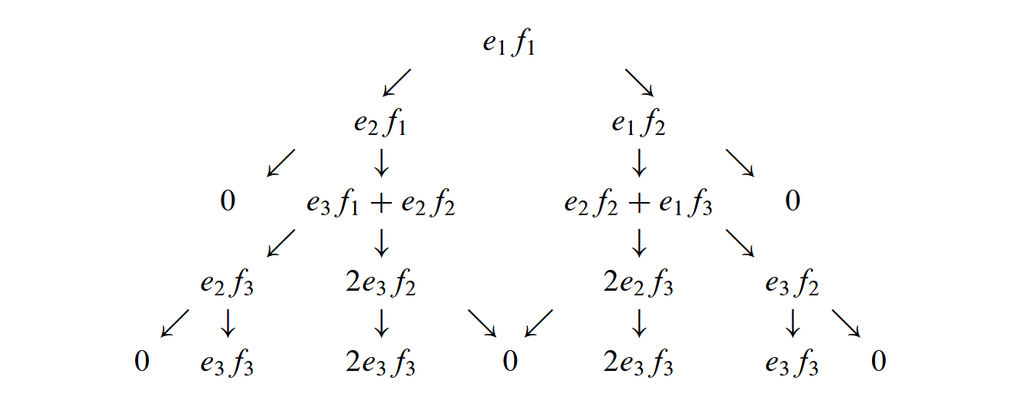

Hall (2015) (p154). $v_{1,1}$ からスタートして，$\pi_{1,1}(Y_1)$ （左矢印）と $\pi_{1,1}(Y_2)$（右矢印）を作用させた．$\otimes$ は省略している．

よって，$W$ の基底は $e_1\otimes f_1,e_2\otimes f_1,e_1\otimes f_2,e_3\otimes f_1+e_2\otimes f_2,e_2\otimes f_2+e_1\otimes f_3,e_3\otimes f_2,e_2\otimes f_3,e_3\otimes f_3$ の8つである．

# 6.6 The Weyl Group

- $\h=\operatorname{span}\{H_1,H_2\}$ を Cartan 部分代数という．

$\SU(3)$ の部分群 $N$ を次で定める：
$$N\coloneqq\{A\in\SU(3)\mid \Ad_{A}(H)\in\h,\quad\forall H\in\h\}.$$

$N$ の正規部分群 $Z$ を次で定める：

$$Z\coloneqq\{A\in N\mid \Ad_{A}(H)=H,\quad\forall H\in\h\}.$$

**Definition 7 (Hall (2015) Definition 6.19 Weyl 群)** $\SU(3)$ の Weyl 群とは，商群 $W\coloneqq N/Z$ のこと．

$w\in W$ から $H\in\h$ への作用を次のように定める．$w$ の代表元 $A$ を選び，$w\cdot H\coloneqq \Ad_{A}(H)$ とする．

**この作用が well-defined であること**

$w$ の代表元として，$B$ を選ぶ．このとき，ある $C\in Z$ が存在して，$B=AC$ である．
$$\Ad_{B}(H)=\Ad_{A}\Ad_{C}(H)=\Ad_{A}(H).$$

- $w\cdot H=H,\enspace\forall H\in\h$ ならば，$w$ は $W$ の単位元

**Proposition 13 (Hall (2015) Proposition 6.20)** $Z$ は $\SU(3)$ の対角行列全体：
$$Z=\{\operatorname{diag}(e^{i\theta},e^{i\phi},e^{-i(\theta+\phi)})\mid \theta,\phi\in\R\}.$$

$N$ は次の形：
$$N=\{A\in\SU(3)\mid \exists k_j\in\{1,2,3\},\exists\theta_j\in\R,\enspace Ae_j=e^{i\theta_j}e_{k_j},\quad j=1,2,3\}．$$
また，Weyl 群 $W$ は要素数3の置換群と同型．

*Proof*. $A\in Z$ とする．$A$ が対角行列であることを示す． $\Ad_{A}(H)=AHA^{-1}=H$ より，$AH=HA$ が任意の $H\in\h$ に対して成り立つ． よって，$AH_1=H_1A$ である．$H_1$ の固有ベクトル $e_1,e_2,e_3$ に対して， $H_1Ae_j=\lambda_jAe_j$ が成り立つ（$\lambda_j$ は固有値で，$\lambda_1=1,\lambda_2=-1,\lambda_3=0$）．よって，$Ae_j$ も $\lambda_j$ の固有空間に属する．$e_j$ の形から，$A$ は対角行列になる．

逆に $\SU(3)$ の対角行列 $A$ が $Z$ に属することを示す．$A$ は $H_1,H_2$ と可換なので，任意の $H\in\h$ と可換．よって，$A\in Z$．

$A\in N$ とする． $AH_1A^{-1}\in\h$ は対角行列である．つまり，$e_1,e_2,e_3$ は $AH_1A^{-1}$ の固有ベクトル．ここで，$Ae_1,Ae_2,Ae_3$ も固有ベクトルになるため，ある $k_j,c\in\C$ が存在して，$Ae_j=ce_{k_j}$ と表される．$A$ はユニタリなので，$|c|=1$ である．

逆に，$A\in\SU(3)$ が $Ae_j=e^{i\theta_j}e_{k_j}$ を満たすなら，$A\in N$ となることを示す．任意の（対角行列）$H\in\h$ に対し，$AH$ は対角行列．また，$e_j^\top A^{-1}=e^{-i\theta_j}e_{k_j}^\top$ に注意すると，$AHA^{-1}$ もまた対角行列で，$AHA^{-1}\in\h$ である．

最後に $W$ が要素数3の置換群と同型であることを示す． $A\in N$ が $e_j$ を $e^{i\theta}e_{k_j}$ に写すなら，$AHA^{-1}$ は $H$ の対角成分を $j\mapsto k_j$ で置換した行列になっている．よって，任意の置換は $N$ の元で表現できる．また，同じ置換を表す $A,B\in N$ は $W$ では剰余類でまとめられているので，$W$ と置換群は同型．

ウェイトを基底の選び方に（もう少し）依らないように定義しなおす．

**Definition 8 (Hall (2015) Definition 6.21 ウェイト)** $\h$ は $\sl(3;\C)$ の Cartan 部分代数とする．$\sl(3;\C)$ の表現 $(\pi,V)$ について，$\lambda\in\h$ が $\pi$ のウェイトであるとは，ある非零の $v\in V$ が存在して，
$$\pi(H)v=\langle\lambda,H\rangle v,\quad H\in\h$$
が成り立つこと．ただし，$\langle\,\cdot\,,\,\cdot\,\rangle$ は Hilbert–Schmidt 内積 $\langle H,H'\rangle\coloneqq \operatorname{trace}(H^*H')$．

- $v$ をウェイトベクトルという．
- ルートも随伴表現について同様に定義する．
- Hilbert-Schimidt 内積は $\h$ 上，Weyl 群の作用に不変．すなわち，$\langle w\cdot H,w\cdot H'\rangle=\langle H,H'\rangle$．
- 基本表現のウェイト $\mu=(1,0),(0,1)$ に対応するウェイトはそれぞれ，$\lambda=\operatorname{diag}(2/3,-1/3,-1/3),\operatorname{diag}(1/3,1/3,-2/3).$
- 正単純ウェイト $\alpha_1,\alpha_2$ に対応するウェイトはそれぞれ $\lambda=\operatorname{diag}(1,-1,0),\operatorname{diag}(0,1,-1).$

**Theorem 6 (Hall (2015) Theorem 6.22)** $\SU(3)$ の表現 $(\Pi,V)$ が誘導する $\sl(3;\C)$ の表現 $(\pi,V)$ について，$\lambda\in\h$ が $\pi$ のウェイトなら，$w\in W$ に対し，$w\cdot \lambda$ もウェイトで，同じ重複度をもつ．

*Proof*. ウェイト $\lambda$ のウェイトベクトルを $v$ とする．$U\in N$ は $w$ の代表元とする．$H\in\h$ に対して，
$$\begin{align*}
\pi(H)\Pi(U)v
&=\Pi(U)\Pi(U)^{-1}\pi(H)\Pi(U)v\\
&=\Pi(U)\pi(U^{-1}HU)v\\
&=\langle \lambda,U^{-1}HU\rangle \Pi(U)v\\
&=\langle \lambda,w^{-1}\cdot H\rangle\Pi(U)v\\
&=\langle w\cdot\lambda,H\rangle\Pi(U)v.
\end{align*}$$

- 2つ目の式変形は Lie 群の準同型とそれが誘導する Lie 代数の準同型の間の関係 $\Pi(U)^{-1}\pi(H)\Pi(U)=\pi(U^{-1}HU)$ から．
- 4つ目の式変形では，$U^{-1}$ を代表元にもつ Weyl 群の元を $w^{-1}$ とした．
- 5つ目の式変形では，Weyl 群の作用に関する内積の不変性を使った．$w\cdot w^{-1}$ が恒等的な作用になっていることは作用の定義の仕方からわかる．

$\Pi(U)$ は $\lambda$ のウェイト空間から $w\cdot\lambda$ のウェイト空間への可逆な写像になっているので，両者の重複度は同じ．

- ルートは Weyl 群の作用によって，ルートに移る．

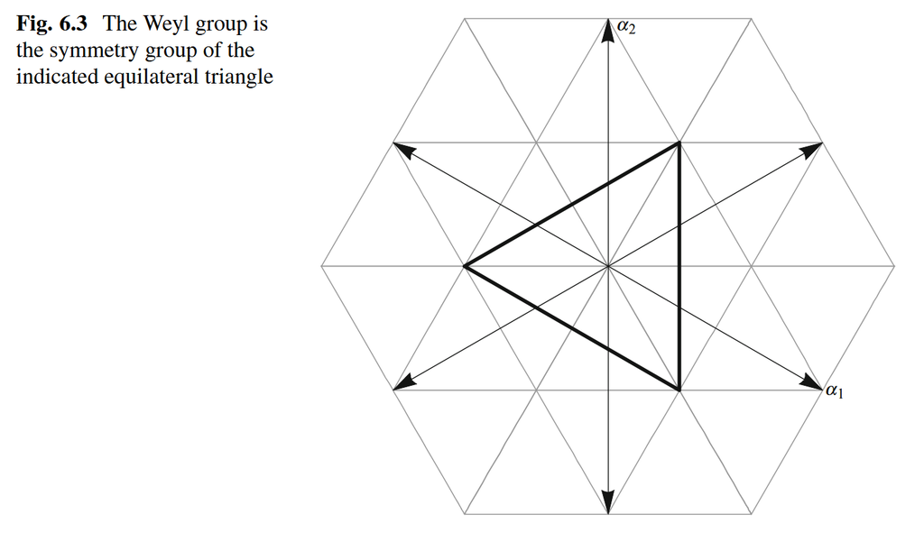

Hall (2015) Fig. 6.3

- 巡回置換 $w_{(1,2,3)}$ によって，$\alpha_1$ は $\alpha_2$ に移る．$\alpha_2$ は $-(\alpha_1+\alpha_2)$ に移る．

**確認**

$w_{(1,2,3)}$ の代表元として，$A=\begin{pmatrix}0&0&1\\1&0&0\\0&1&0\end{pmatrix}$ が選べる．実際に作用を求めてみると，
$$\begin{align*}
w_{(1,2,3)}\cdot\alpha_1
&=A\begin{pmatrix}1&0&0\\0&-1&0\\0&0&0\end{pmatrix}A^{-1}
=\begin{pmatrix}0&0&0\\0&1&0\\0&0&-1\end{pmatrix}=\alpha_2\\
w_{(1,2,3)}\cdot\alpha_2
&=A\begin{pmatrix}0&0&0\\0&1&0\\0&0&-1\end{pmatrix}A^{-1}
=\begin{pmatrix}-1&0&0\\0&0&0\\0&0&1\end{pmatrix}=-(\alpha_1+\alpha_2)
\end{align*}$$

となる．

- 互換 $w_{(1,2)}$ によって，$\alpha_1$ は $-\alpha_1$ に移る．$\alpha_2$ は $\alpha_1+\alpha_2$ に移る．

**確認**

$w_{(1,2)}$ の代表元として，$A=\begin{pmatrix}0&-1&0\\-1&0&0\\0&0&-1\end{pmatrix}$ が選べる．実際に作用を求めてみると，
$$\begin{align*}
w_{(1,2)}\cdot\alpha_1
&=A\begin{pmatrix}1&0&0\\0&-1&0\\0&0&0\end{pmatrix}A^{-1}
=\begin{pmatrix}-1&0&0\\0&1&0\\0&0&0\end{pmatrix}=-\alpha_1\\
w_{(1,2)}\cdot\alpha_2
&=A\begin{pmatrix}0&0&0\\0&1&0\\0&0&-1\end{pmatrix}A^{-1}
=\begin{pmatrix}1&0&0\\0&0&0\\0&0&-1\end{pmatrix}=\alpha_1+\alpha_2
\end{align*}$$

となる．

- $\langle \lambda,H_i\rangle,(i=1,2)$ が整数になるような $\lambda\in\h$ を整元 (integral element) という．
- $\langle \lambda,H_i\rangle\geq0,(i=1,2)$ を満たす $\lambda\in\h$ を優元 (dominant element) という．

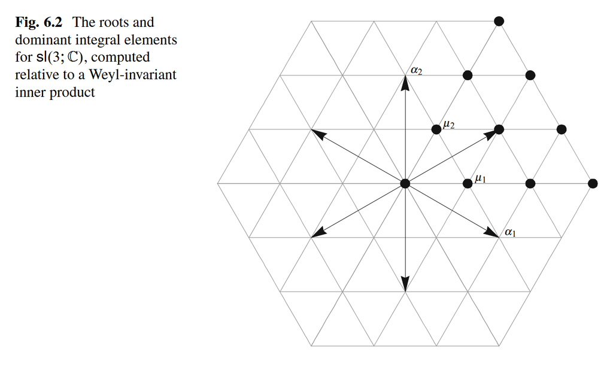

Hall (2015) Fig. 6.2

# 6.7 Weight Diagrams

いくつかの最高ウェイトに関するウェイトの図．

- 黒線は優ウェイトの境界
- 黒点はウェイト，丸がついているのは最高ウェイト
- 破線は最高ウェイトの境界
- 数字は対応するウェイト空間の重複度

Lemma 1 をつかって，$(0,0)$ か $(0,1)$ から出発して最高ウェイトにたどり着ける．

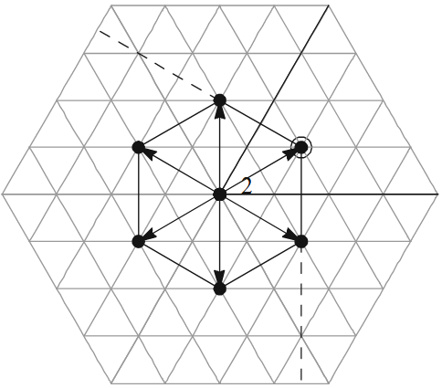

Hall (2015) Fig. 6.4 最高ウェイト $(1,1)$

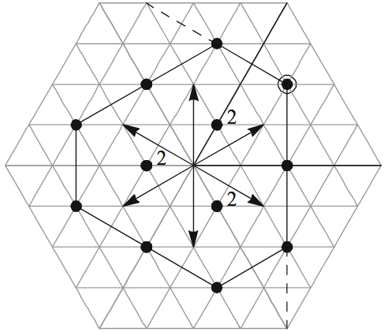

Hall (2015) Fig. 6.4 最高ウェイト $(1,2)$

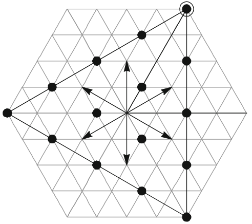

Hall (2015) Fig. 6.4 最高ウェイト $(0,4)$

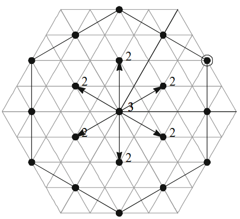

Hall (2015) Fig. 6.4 最高ウェイト $(2,2)$

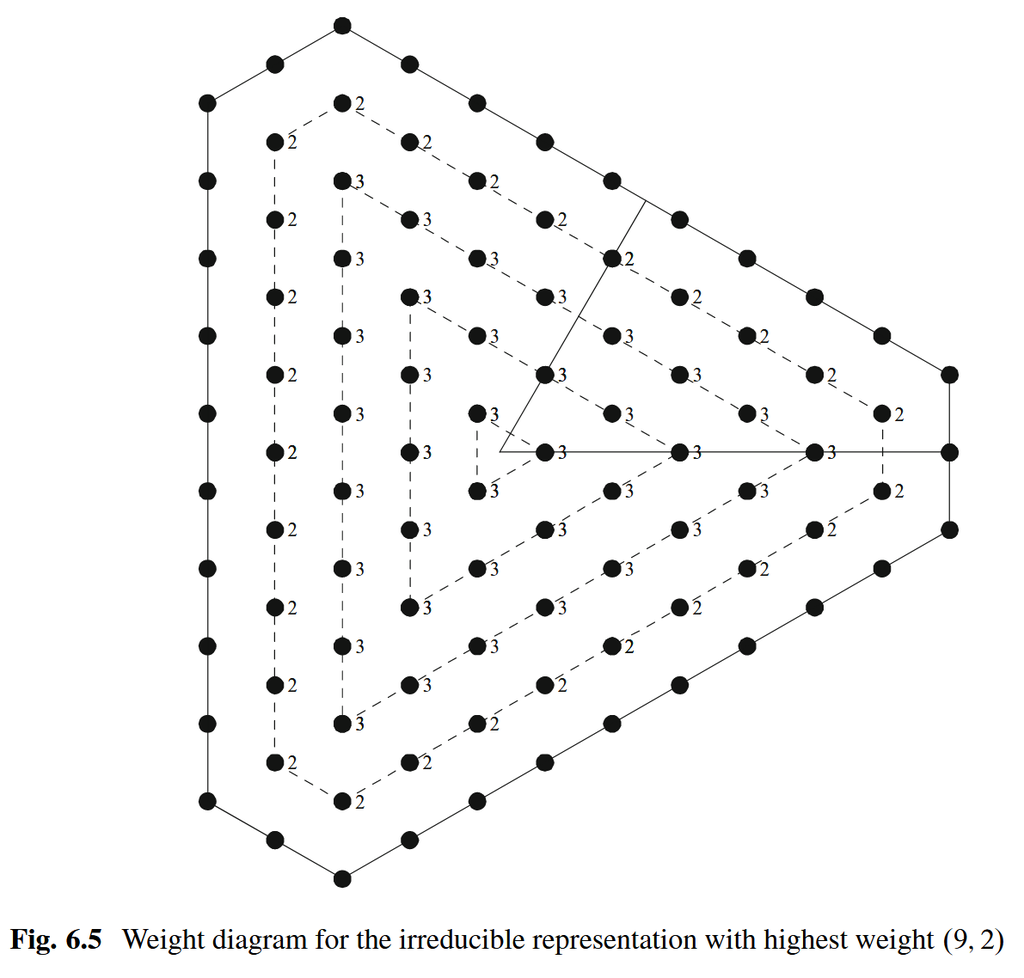

Hall (2015) Fig. 6.5 最高ウェイト $(9,2)$

- 最高ウェイト $(9,2)$ に対応する既約表現はもはや計算できないが，6.8 節の結果で，ウェイトは特定できる．重複度は10章の Kostant の重複度の公式を使って計算できるらしい．

# 6.8 Further Properties of the Representations

最高ウェイト定理だけでは以下のことはわからない．

1. 最高ウェイト以外のウェイトは？
2. それらのウェイトの重複度は？
3. 表現の次元は？

**Definition 9 (Hall (2015) Definition 6.23 凸包)** $v_1,\dots,v_N$ は実（複素）線形空間の元とする． $v_1,\dots,v_N$ の凸包 (convex hull) とは，以下の集合のこと．
$$\{c_1v_1+\cdots+c_Nv_N\mid c_j\in[0,\infty), c_1+\cdots+c_N=1\}$$

**Theorem 7 (Hall (2015) Theorem 6.24)** $\mu$ は整かつ優ウェイトで，$(\pi,V_\mu)$ は最高ウェイトが $\mu$ の既約表現とする．$\lambda$ が $\pi$ のウェイトならば，$\lambda$ は以下を満たす．

1. $\mu-\lambda$ はルートの整数係数の線形結合で表せる．
2. $\lambda$ は $W\cdot\mu\coloneqq\{w\cdot\mu\mid w\in W\}$ の凸包に含まれる．

*Proof*. 1つ目の条件：

$v$ を最高ウェイトベクトルとする． Proposition 7 の証明（+Proposition 8）から，
$$V_\mu=\operatorname{span}\{\pi(Y_{j_1})\pi(Y_{j_2})\cdots\pi(Y_{j_N})v\mid j_k\in\{1,2,3\},N\geq0\}$$

が成り立っている．$V_\mu$ を張るベクトルはウェイト $\mu-\alpha_{j_1}-\cdots-\alpha_{j_N}$ に関するウェイトベクトル．よって，$V_\mu$ の任意のウェイトは1つ目の条件を満たす．

2つ目の条件（直感的な証明）：

Theorem 6 より，$w\cdot\mu,w\in W$ もウェイトである．もし，$\lambda\not\in W\cdot\mu$ ならば，$\mu\not\succeq w\cdot\lambda$ となる $w\in W$ が存在することになる．

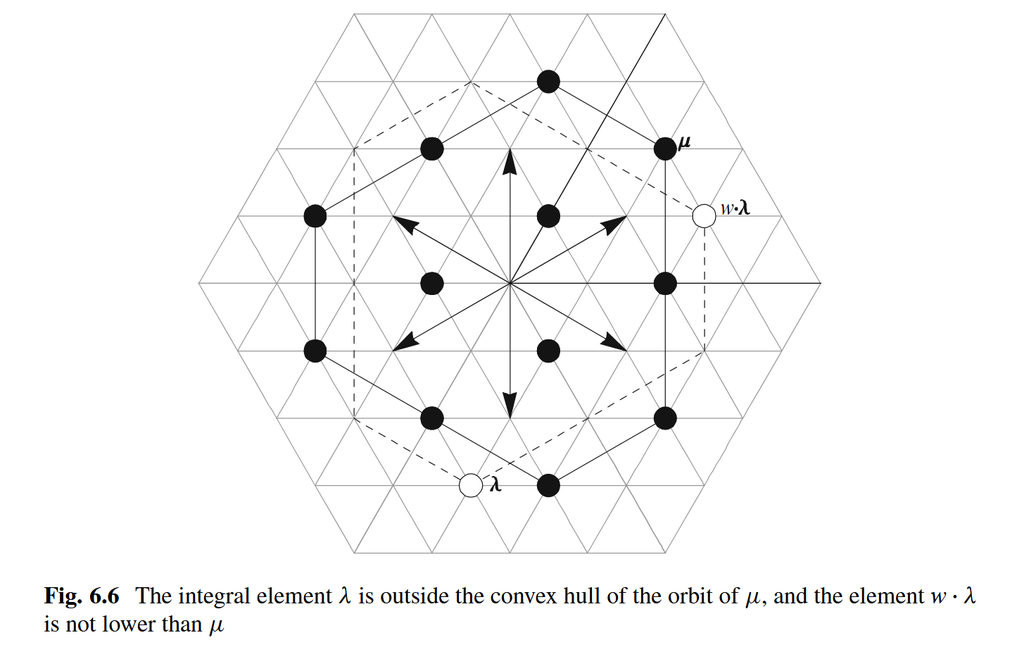

Hall (2015) Fig. 6.6

2つ目の条件（フォーマルな証明）：

任意のウェイト $\lambda$ について，ある $w\in W$ が存在して，$\lambda'\coloneqq w\cdot\lambda$ を優ウェイトにできる（ルートに対して，Weyl 群の作用が鏡像・回転になっているから）． $\mu\succeq\lambda'$ なので，$\lambda'$ は下図の灰色の四角形 $Q_\mu$ に含まれている．

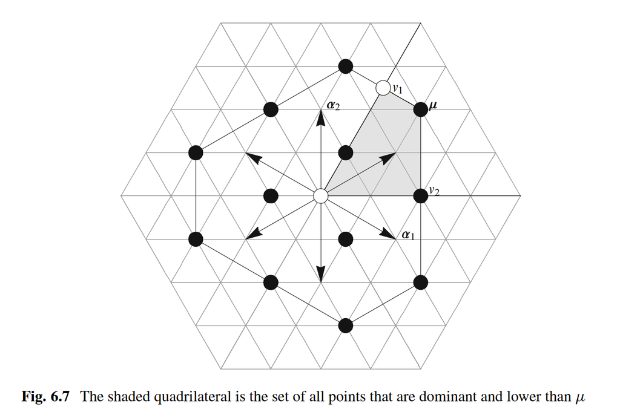

Hall (2015) Fig. 6.7

この四角形のすべての頂点が $W\cdot\mu$ の凸包 $E_\mu$ に含まれていることを示す． まず，$W\cdot\mu$ は $\mu$ の鏡像と（120度）回転で表せる（有限個）点の集合で，その重心は $0$ なので，$0\in E_\mu$ である．$s_{\alpha_j}\in W$ を鏡像に対応する作用とすると，
$$v_j=\frac12(\mu+s_{\alpha_j}\cdot\mu)\in E_\mu$$

である．

以上より，$\lambda'\in E_\mu$ が示せた．$W\cdot\mu$ は $W$ の作用に閉じているので，$E_\mu$ もそう．よって，$\lambda=w^{-1}\lambda'\in E_\mu$ である．

**Theorem 8 (Hall (2015) Theorem 6.25)** $(\pi,V_\mu)$ を最高ウェイト $\mu$ をもつ既約表現とする．$\lambda$ は Theorem 7 の条件を満たす整元とすると，$\lambda$ は $\pi$ のウェイト．

*Proof*. 仮定より，$n_1,n_2\in\mathbb{Z}$ を用いて，$\lambda=\mu-n_1\alpha_1-n_2\alpha2$ と表せる．

$n_1\geq n_2$ を仮定する．$\alpha_3\coloneqq\alpha_1+\alpha_2$ とすると， $\lambda=\mu-(n_1-n_2)\alpha_1-n_2\alpha_3$ である． $\lambda$ から出発して，$\alpha_3$ の方向に進むと，$W\cdot\mu$ の凸包 $E_\mu$ の境界に点 $\gamma\coloneqq\mu-(n_1-n_2)\alpha_1$ でぶつかる．

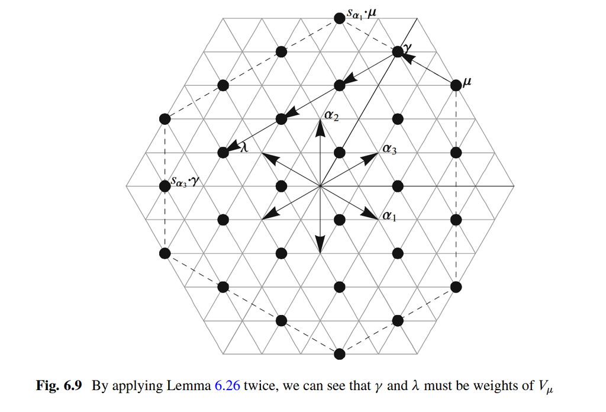

Hall (2015) Fig. 6.9

$\gamma\in E_\mu$ は $\mu$ と $s_{\alpha_1}\cdot\mu$ の間に存在する．Lemma 4 より，$\gamma$ はウェイト．

$n_1\leq n_2$ の場合も同様．

**Lemma 4 (Hall (2015) Lemma 6.26)** $\gamma$ は $\pi$ のウェイト，$\alpha$ はルートとして，$s_\alpha\in W$ を対応する鏡像変換とする．2点 $\gamma,s_\alpha\cdot\gamma$ を結ぶ線分上の点 $\lambda$ が $\gamma-\lambda=c\alpha,\exists c\in\mathbb{Z}$ を満たすなら，$\lambda$ は $\pi$ のウェイト．

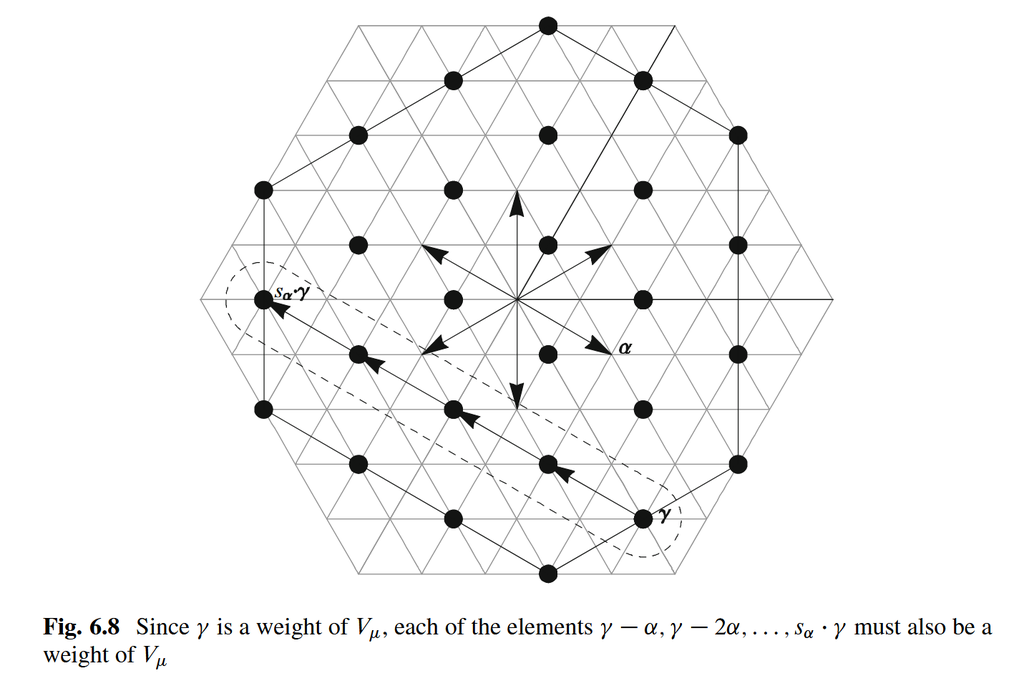

Hall (2015) Fig. 6.8

*Proof*. $s_{\alpha}=s_{-\alpha}$ なので，$\alpha_1,\alpha_2,\alpha_3\coloneqq\alpha_1+\alpha_2$ だけ考えれば十分．$H_3\coloneqq H_1+H_2$ とすると，$\operatorname{span}\{X_j,Y_j,H_j\}\simeq\sl(2;\C),\enspace j=1,2,3$ である．

内積の線形性から，$\langle\lambda,H_j\rangle$ は $\langle\gamma,H_j\rangle$ と $\langle s_\alpha\cdot\gamma,H_j \rangle=\langle \gamma,s_\alpha H_j\rangle=-\langle \gamma,H_j\rangle$ の間に値をとる．仮定より， $\langle\gamma,H_j\rangle-\langle\lambda,H_j\rangle=c\langle\alpha_j,H_j\rangle=2c$ が成り立つ．

$U_j\coloneqq\operatorname{span}\{v\in V_\mu\mid v\text{ は }\gamma+k\alpha_j\text{ のウェイトベクトル},k\in\R\}$ とすると，$(\pi,U_j)$ は $\sl(2;\C)$ の表現．

**Tip 7**

$U_j$ が $\pi$ の作用に閉じていることは，Lemma 1 からわかる．

$\langle\gamma,H_j\rangle$ は $\pi(H_j)$ の固有値なので，Theorem 2 より，$\langle\lambda,H_j\rangle$ もまた $\pi(H_j)$ の固有値． その固有ベクトル $w\in U_j$ はウェイト $\lambda=\gamma-c\alpha$ のウェイトベクトルになっている．

## References

Folland, Gerald B. 2016. *A Course in Abstract Harmonic Analysis*. CRC press.

Hall, Brian C. 2015. *Lie Groups, Lie Algebras, and Representations: An Elementary Introduction*. Vol. 222. Graduate Texts in Mathematics. Cham: Springer International Publishing. https://doi.org/10.1007/978-3-319-13467-3.

Kim, Peter T. 1998. “Deconvolution Density Estimation on SO(n).” *The Annals of Statistics* 26 (3): 1083–1102.

Stefanski, Leonard A, and Raymond J Carroll. 1990. “Deconvolving Kernel Density Estimators.” *Statistics* 21 (2): 169–84.